# visStatistics

Sabine Schilling

2021-08-29

```r
library(visStatistics)
```

# Abstract

Statistical consulting requires often both a quick first visualization and a reproducible statistical analysis of the presented raw data. The R package `visStatistics` with its core function `visstat()` fulfils this need. Based on a decision tree it picks the statistical hypothesis test with the highest statistical power between the dependent variable (response) named `varsample` and the independent variable (feature) named `varfactor` in a `data.frame` named `dataframe`. Data in the provided `dataframe` must be structured column wise, where `varsample` and `varfactor` are the character strings of the column names of the dependent and independent variable respectively.

The corresponding test statistics including eventual post-hoc-analysis are returned and a graph showing key statistics of the underlying test is generated. This fully automated workflow is especially suited for browser based interfaces to server-based deployments of R and has been successfully implemented to analyse medical raw data in an unbiased fashion.

The statistical tests performed by the core function `visstat` depend on the type of the data (numerical/integer or categorical), the number of levels whilst dealing with categorical data and the data distributions. The reminder of this vignette documents in detail the algorithm underlying the decision tree of `vistat()`.

# 1 Comparing means and medians

If the feature `varfactor` has two or more levels and the response `varsample` is of type numerical or integer, tests to compare the means or medians of the sample are applied. The used confidence levels `conf.level` defaults to 0.95, but can be adapted in the function call to `visstat()`.

## 1.1 Two sample tests: Welch’s t-Test or Wilcoxon rank sum test

- If the sample size of both samples is bigger than 100, the function `visstat()` performs always **Welch’s t-Test** (`t.test()`) (Lumley et al. 2002 ).

  The graphical representation names the used test, the underlying null hypothesis with the associated p-value of the null hypothesis. A box plot with an overlayed jitter plot showing each data point is generated. The number of data entry of each sample is displayed above each box. The means and confidence intervals are displayed in red. The confidence intervals are corrected for the familywise error rate in pairwise comparison by the Sidak method (Šidák 1967) (see section 1.2).

  The test statistics of the Shapiro-Wilk test on the standardized residuals as well of Welch’s t-test are returned as a list.
- If the sample size of one of the samples is smaller than 100, `viststat()` checks for the normality of the standardized residuals of both samples with the Shapiro-Wilk Normality Test (`shapiro.test()`). If the normality assumption is met, Welch’s t-Test is performed, otherwise the Wilcoxon rank sum test. The detailed algorithm is:
  - If the p-values of the standardized residuals of both distributions in the `shapiro.test()` are bigger than the error probability `1-conf.level`, **Welch’s t-Test** (`t.test()`) is executed. Otherwise,
  - if the p-values of the standardized residuals of both distributions in the `shapiro.test()` are smaller than the error probability `1-conf.level`, a **Wilcoxon rank sum test** (`wilcox.test()`) is executed.

  The graphical representation is analogue to Welch’s t-test omiting mean and confidence interval. The test statistics of the Wilcoxon rank sum test as well as the summary statistics of the generated boxplots is generated and returned as a list.

### 1.1.1 Examples

#### 1.1.1.1 Welch’s t-test calling t.test()

```r
mtcars$am=as.factor(mtcars$am)
ttestStatistics=visstat(mtcars,"mpg","am")
```

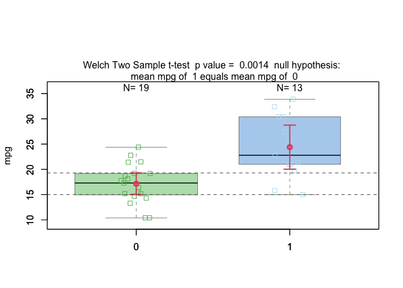

```r
#  uncomenting the next line prints out test statistics
# ttestStatistics
```

```r
#Increasing the confidence level
ttestStatistics=visstat(mtcars,"mpg","am",conf.level=0.99)
```

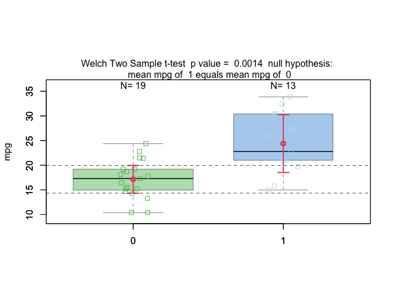

#### 1.1.1.2 Wilcoxon rank sum test (calling wilcox.test())

```r
grades_gender <- data.frame(
Sex = as.factor(c(rep("Girl", 20), rep("Boy", 20))),
Grade = c(19.3, 18.1, 15.2, 18.3, 7.9, 6.2, 19.4,
            20.3, 9.3, 11.3, 18.2,17.5,10.2,20.1,13.3,17.2,15.1,16.2,17.3,
            16.5, 5.1, 15.3, 17.1, 14.8, 15.4, 14.4, 7.5, 15.5, 6.0,17.4,
            7.3, 14.3,13.5,8.0,19.5,13.4,17.9,17.7,16.4,15.6))

wilcoxonStatistics=visstat(grades_gender,"Grade", "Sex")
```

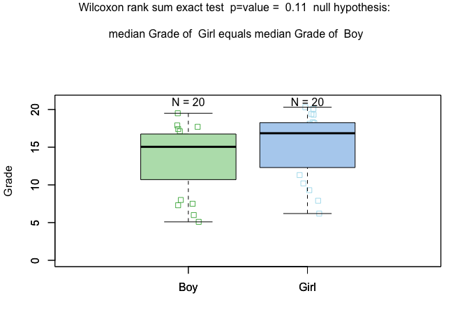

## 1.2 More than two samples: One Way Test and ANOVA or Kruskal-Wallis-Test

If the feature `varfactor` has more than two levels and the response `varsample` is of type numerical or integer, the underlying assumptions of the analysis of variance, normality of the standardized residuals and homoscedacity, are checked by the function `vis_anova_asumptions()`.  
### Residual analysis

It checks for the normality of the standardised residuals of the analysis of variance (ANOVA) fit generated by the function `aov()` . To do so it applies both the Shapiro-Wilk-test `shapiro.test()` and the Anderson-Darling-Test `ad.test()` on the standardized residuals. Furthermore the data is graphically analysed by plotting the standardized residuals versus the fitted mean values of the linear model for each level of `varfactor`. Additionally the normal QQ plot of the standardized residuals is generated.

### 1.2.1 Check for homogenity of variances in each level: Bartlett test

Both `aov()` and `oneway.test()` check, whether two or more samples from normal distributions have the same mean. Whereas `aov()` requires homogeneity of variances in each level (group), the `oneway.test()` does not assume that the variances in each group are necessarily equal. Homoscedacity is tested with the `bartlett.test()`. It performs Bartlett’s test of the null hypothesis that the variances in each of the levels are the same.

### 1.2.2 One Way Test and ANOVA

Depending on the p-value of the `bartlett.test()` the appropriate test is chosen:

- If the p-value of the `bartlett.test()` is bigger than `1-conf.level`, we can assume homogenity of variances in each level (group) and the p-values of `aov()` is displayed.
- Otherwise homoscedacity can not be assumed and the p-value of `oneway.test()` is displayed.

The generated graphs shows in blue the mean plus/minus the standard deviation of each group. To generate the Sidak corrected confidence intervals in red, we entered the applied corrected probability of error for the comparison of $M$ groups,

$\alpha_{Sidak}=1-$`conf.int`$^{1/M}$, (Šidák 1967) in the standard formula for confidence intervals
$$\left[{{\overline {x}}-t_{\left(1-{\frac {\alpha_{Sidak} }{2}};n-1\right)}{\frac {s}{\sqrt {n}}}\ ;\ {\overline {x}}+t_{\left(1-{\frac {\alpha_{Sidak} }{2}};n-1\right)}{\frac {s}{\sqrt {n}}}}\right],$$
where $\overline {x}$ is the mean, $s$ the standard deviation and $n$ the number of entries of each group (level).

Note that the current structure of `visstat()` does not allow the study of interactions between the different levels of the independent variable.

#### 1.2.2.1 Post-hoc analysis: Tukey Honest Significant Differences

We use the Tukey Honest Significant Differences `TukeyHSD()` to create a set of confidence intervals on the differences between the means of the levels of a factor with the specified family-wise probability `conf.level`. This list of confidence intervals accompanied by the adjusted p-values is returned. If the difference between two levels is significant at the given `conf.level`, the displayed letters at the bottom of the graph between the two levels will differ. Note that the Tukey HSD requires homoscedacity of the samples. In a future revision of `visStatistics` an approriate post-hoc test for non homogeneous data will be included.

### 1.2.3 Kruskal-Wallis-Test

If the p-values of the standardized residuals calculated by `shapiro.test()` or `ad.test()` are smaller than the error probability `1-conf.level`, a normal distribution of the residuals can not be assumed. In this case, `visstat()` chooses a non-parametric alternative, the Kruskal-Wallis rank sum test. `kruskal.test()` tests the null that the medians are the same in each group (level). As post-hoc-analysis the `pairwise.wilcox.test()` applying the default Holm method (Holm 1979) is used. If two groups differ significantly at the given `conf.level`, the green letters below the box plot differ. Otherwise the graphical representation of the Kruskal-Wallis test is analogue to the above described Wilcoxon rank sum test. A list wtih the test statistics of the Kruskal-Wallis rank sum test as well as the p-values of the pairwise comparisons adjusted by the Holm method is returned.

### 1.2.4 Examples

The `npk` data sets reports the yield of peas in pounds/block on 6 blocks.

#### 1.2.4.1 One way test

```r
 oneway_npk=visstat(npk,"yield","block")
```

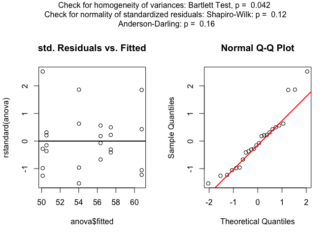

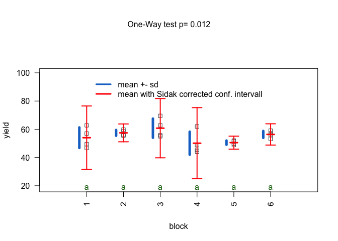

The post-hoc analysis with `TukeyHSD()` reveals no significant difference between the yield in all blocks (all green letters are the same). #### ANOVA

To stabilize the variance we transform the count data with the square root.

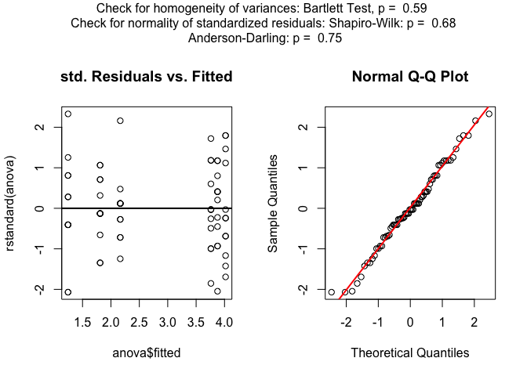

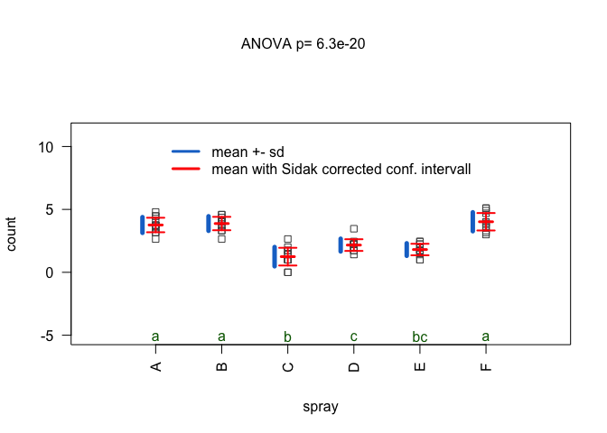

```r
InsectSprays_tr=InsectSprays
InsectSprays_tr$count=sqrt(InsectSprays$count)
visstat(InsectSprays_tr, "count", "spray")
```

#### 1.2.4.2 Kruskal-Wallis rank sum test

The iris data set gives the measurement of the petal width in cm for three different iris species.

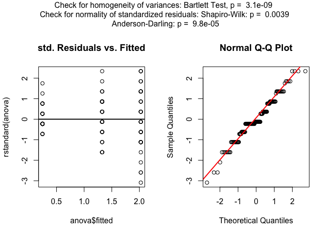

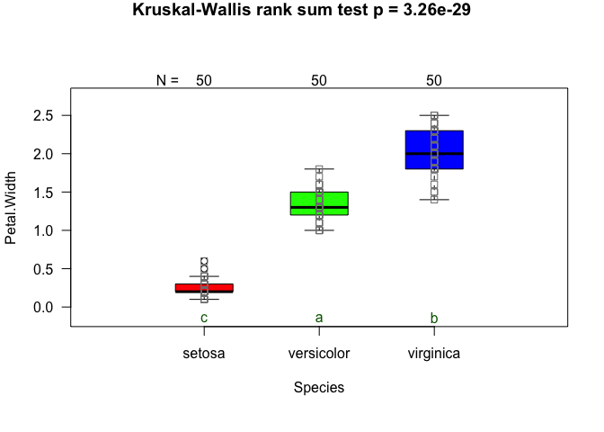

```r
visstat(iris,"Petal.Width", "Species")
```

In the iris data example, both the graphical analysis by the scatter plots of the standardized residuals and the QQ -plot as well as the p-values of Shapiro-Wilk-test and Anderson-Darling test suggest that we can not assume that the residuals are normally distributed. Therefore `visstat` switches to the non parametric alternative `kruskal.test()`.

# 2 Linear Regression

If the feature `varfactor` and the response `varsample` have only one level of type `numerical` or `integer`, `visstat()` performs a simple linear regression

## 2.1 Residual analysis

Independent of the residual analysis outcome, `visstat()`` performs in the subsequent step the regression itself. The title of the graphical output lists the chosen confidence level `conf.level`, the regression parameter accompanied by their confidence levels and p-values as well as the adjusted $R^2$. The graph shows the raw data, the regression line and both the confidence and prediction bands corresponding to the chosen `conf.level`. The function returns a list with the test statistics of the linear regression, the p-values of the normality tests of the standardized residuals and the pointwise estimates of the confidence and prediction band.

## 2.2 Example

### 2.2.1 cars

The cars data set reports the speed in mph of cars and the distances (dist) in ft taken to stop.

```r
linreg_cars=visstat(cars,"dist","speed")
```

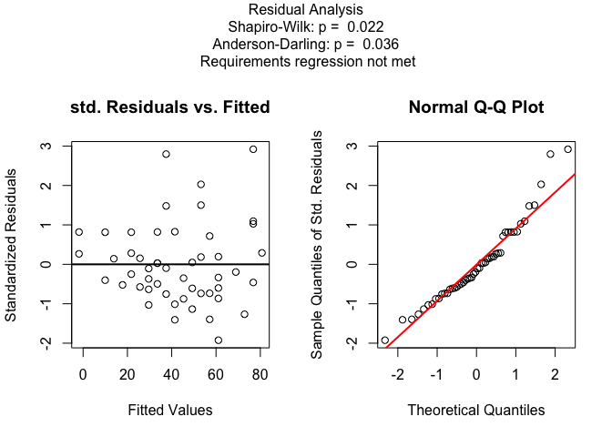

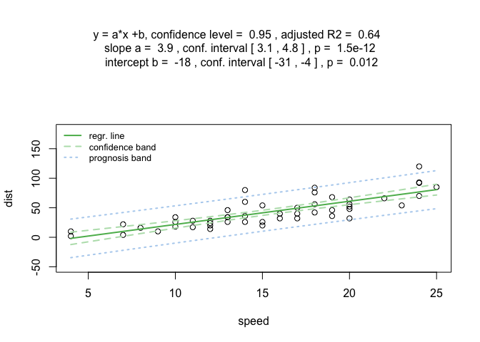

Increasing the confidence level `conf.level` from the default 0.95 to 0.99 leads two wider confidence and prediction bands:

```r
linreg_cars=visstat(cars,"dist","speed",conf.level=0.99)
```

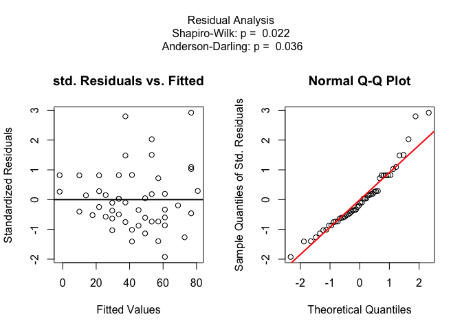

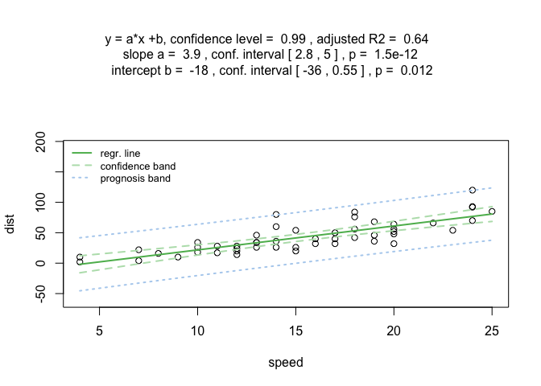

```r
#Extract the test statistics
linreg_cars$anderson_darling_test_residuals
```

```
#>
#>  Anderson-Darling normality test
#>
#> data:  rstandard(lm(y ~ x))
#> A = 0.8005, p-value = 0.03555
```

```r
linreg_cars$shapiro_test_residuals
```

```
#>
#>  Shapiro-Wilk normality test
#>
#> data:  rstandard(lm(y ~ x))
#> W = 0.94518, p-value = 0.0217
```

### 2.2.2 trees

The trees data set provides measurements of the diameter (named “Girth”) in inches and height in feet of black cherry trees.

```r
linreg_cars=visstat(trees,"Height","Girth",conf.level=0.9)
```

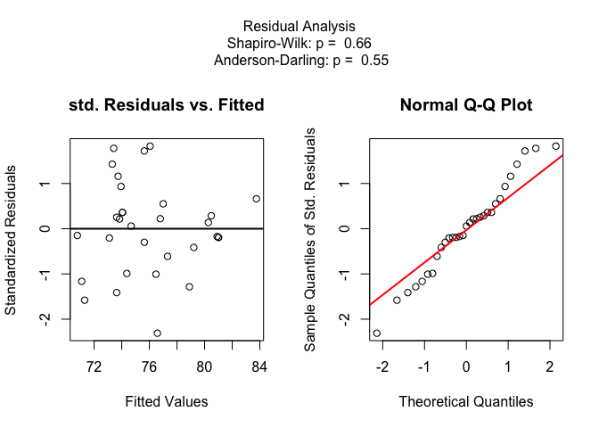

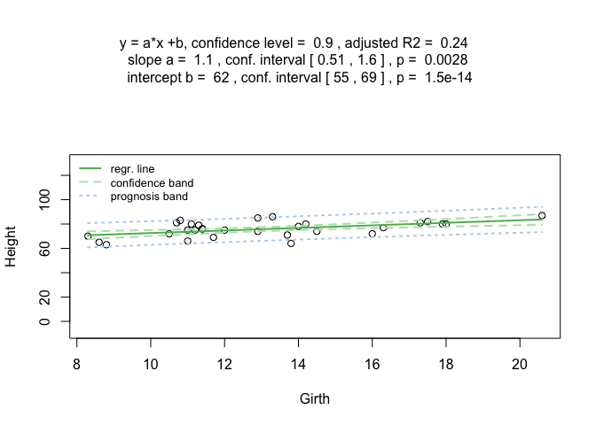

# 3 ${\chi}^2$- and Fisher Test

If both the feature `varfactor` and the response are `varsample` are categorical of type `factor`, `visstat` performs a test for the independence of count data. Based on Cochran’s rule (Cochran 1954), either a ${\chi}^2$- or a Fisher Test are performed:

- If more than 20 percent of all cells have a count smaller than 5, `fisher.test()` is performed and displayed,
- otherwise the `chisqu.test()`.

In both cases grouped column charts and an additional mosaic plot showing Pearson’s residuals are generated.

# 4 Contingency tables:

Unbuilt data sets of count data present the data often as multidimensional arrays.

## 4.1 Examples

### 4.1.1 Pearson’s Chi-squared test and mosaic plot with Pearson residuals

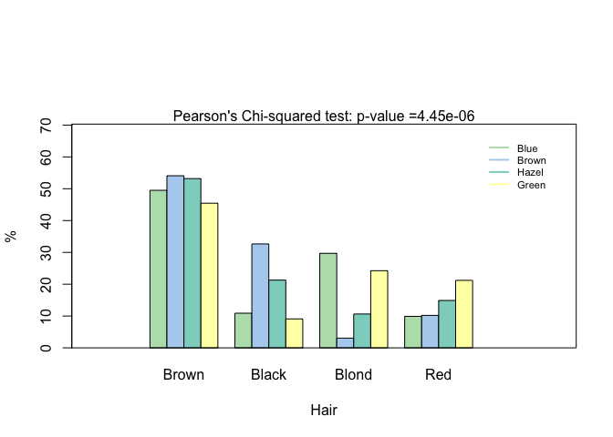

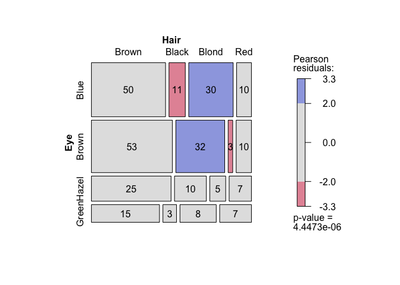

```r
visstat(counts_to_cases(as.data.frame(HairEyeColor[,,1])),"Hair","Eye")
```

### 4.1.2 2x2 contingency tables with Fisher’s exact test and mosaic plot with Pearson residuals

```r
HairEyeColorMaleFisher = HairEyeColor[,,1]
#slicing out a 2 x2 contingency table
blackBrownHazelGreen = HairEyeColorMaleFisher[1:2,3:4]
blackBrownHazelGreen = counts_to_cases(as.data.frame(blackBrownHazelGreen));
fisher_stats=visstat(blackBrownHazelGreen,"Hair","Eye")
```

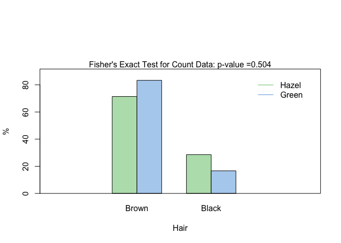

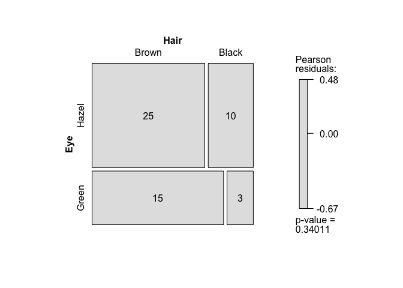

```r
# fisher_stats  #uncommenting prints out summary statistics
```

# 5 Saving the graphical output

The generated graphs can be saved in the file formats supported by `Cairo():` “png”, “jpeg”, “pdf”, “svg”, “ps” and “tiff”. In the following example we save the graphics files in the output format “png” to the `plotDirectory` `tempdir()`. The applied naming convention of the graphics file reflects the chosen statistical test and the variable names.

```r
visstat(blackBrownHazelGreen,"Hair","Eye",graphicsoutput = "png",plotDirectory=tempdir())
```

Remove the graphical output from `plotDirectory`

```r
 file.remove(file.path(tempdir(),"chi_squared_or_fisher_Hair_Eye.png"))
```

```
#> [1] TRUE
```

```r
 file.remove(file.path(tempdir(),"mosaic_complete_Hair_Eye.png"))
```

```
#> [1] TRUE
```

# 6 Overview of implemented tests

`t.test()`, `wilcox.test()`, `aov()`, `kruskal.test()`, `lm()`,`fisher.test()`, `chisqu.test()`

## 6.1 Implemented tests to check the normal distribution of standardized residuals

`shapiro.test()` and `ad.test()`

## 6.2 Implemented post-hoc tests

`TukeyHSD()` for `aov()` and `pairwise.wilcox.test()` for `kruskal.test()`.

# Bibliography

Cochran, William G. and. 1954. “The combination of estimates from different experiments.” *Scandinavian Journal of Statistics* 10 (1): 101–20. https://doi.org/10.2307/3001666.

Holm, S. 1979. “A Simple Sequentially Rejective Multiple Test Procedure.” *Scandinavian Journal of Statistics* 6: 65–70.

Lumley, Thomas, Paula Diehr, Scott Emerson, and Lu Chen. 2002. “The importance of the normality assumption in large public health data sets.” *Annual Review of Public Health* 23: 151–69. https://doi.org/10.1146/annurev.publhealth.23.100901.140546.

Šidák, Zbyněk. 1967. “Rectangular Confidence Regions for the Means of Multivariate Normal Distributions.” *Journal of the American Statistical Association* 62 (318): 626–33. https://doi.org/10.1080/01621459.1967.10482935.